# Improved Classification with Super Learner

Emily Robinson  
Dec. 2018

### Motivating Example

How many Christmas candies are in the jar?

- Some individuals guessed over.
- Some individuals guessed under.
- What if we average all of the guesses?

### Ensemble Learning (Stacking)

Definition: A procedure where multiple learner modules are applied on a dataset to extract multiple predictions, which are then combined into one composite prediction.

Three Steps:

- Ensemble Generation
  - Homogeneous if all base models belong to the same class of models.
  - Heterogeneous if all base models belong to a diverse set of models.
- Ensemble Pruning
- Ensemble Integration

Diversity is considered one of the key success factors of ensembles.

(Unknown, 2018)

### Weighted Average

Suppose that \( M \) predictors are available, \( \hat{f_1}, \hat{f_2}, ..., \hat{f_M} \). Under a loss or risk function, a weight vector \( \textbf{w} \) is created and the predictor \[ \hat{f}(x)=\sum_{i=1}^{M}w_i\hat{f_i}(x). \]

How do you determine opitimum weights?

- Minimize mean square error.
- Maximize area under the curve (AUC) of receiver operating characteristic (ROC).

```r
library(SuperLearner)
```

(Unknown, 2018)

### Diabetes Dataset

The dataset I have selected for my project is the Pima Indians Diabetes Database found on Kaggle through the UCI data repository https://www.kaggle.com/uciml/pima-indians-diabetes-database, originally from the National Institute of Diabetes and Digestive and Kidney Diseases.

- Females at least age 21 years old and of Pima Indian heritage
- Target variable, Outcome, is binary and indicates whether or not a patient has diabetes
- The objective is to correctly classify individuals to have diabetes or not based on several medical predictor variables such as the number of pregnancies the patient has had, their BMI, insulin level, age, etc.

```
[1] "Pregnancies"              "Glucose"
[3] "BloodPressure"            "SkinThickness"
[5] "Insulin"                  "BMI"
[7] "DiabetesPedigreeFunction" "Age"
[9] "Outcome"
```

### Diagnostics

```
No Studentized residuals with Bonferonni p < 0.05
Largest |rstudent|:
    rstudent unadjusted p-value Bonferonni p
350 2.967294          0.0030043           NA
```

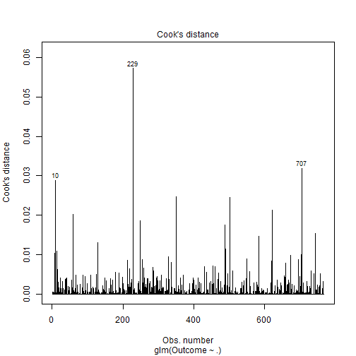

### Diagnostics

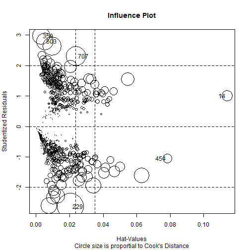

```
      StudRes         Hat       CookD
14   1.002281 0.114022424 0.009536169
229 -2.634163 0.020610966 0.057205591
350  2.967294 0.003069042 0.024729204
454 -1.057796 0.078351507 0.007159288
503  2.786460 0.005137660 0.024505179
707  2.306667 0.023944183 0.031920741
```

### Collinearity

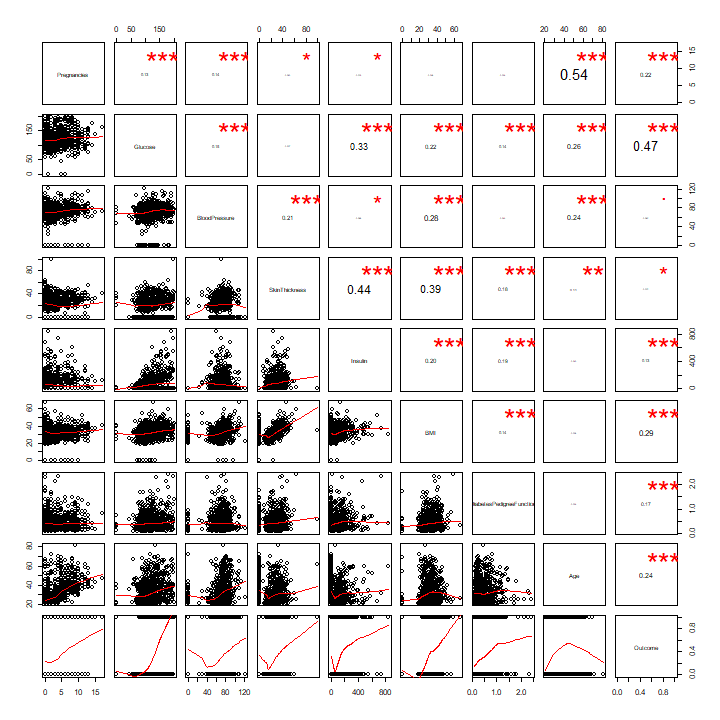

### Data Preparation

```r
# Create response and predictor sets
Diabetes <- Diabetes[-c(14, 229, 350, 454, 503, 707),]
outcome  <- Diabetes$Outcome
data     <- subset(Diabetes, select = -Outcome)

# Create train & test sets
set.seed(904)
pct = 0.6
train_obs = sample(nrow(data), floor(nrow(data)*pct))
X_train = data[train_obs, ]
X_holdout = data[-train_obs, ]
Y_train = outcome[train_obs]
Y_holdout = outcome[-train_obs]

table(Y_train, useNA = "ifany")
```

```
Y_train
  0   1
290 167
```

### Explore Dataset

```r
glm_mod2 <- glm(Outcome ~., data = Diabetes, family = binomial())
glm_mod2$coefficients
```

```
             (Intercept)              Pregnancies                  Glucose
            -9.033836090              0.120943571              0.038777313
           BloodPressure            SkinThickness                  Insulin
            -0.013052960             -0.001082154             -0.001094749
                     BMI DiabetesPedigreeFunction                      Age
             0.092884435              1.146457478              0.014083702
```

### Added Variable Plots

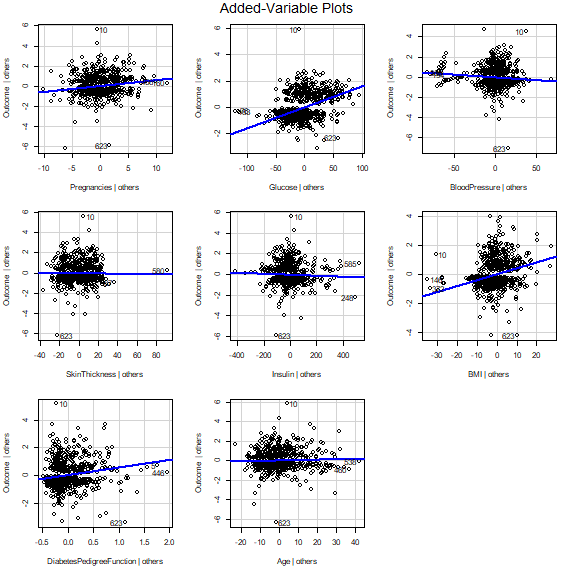

```r
avPlots(glm_mod2)
```

### Variable Importance

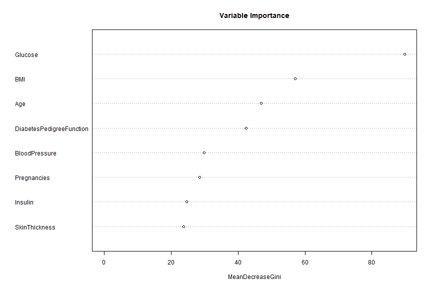

```r
library(randomForest)
rf_mod <- randomForest(factor(Outcome) ~ ., data = Diabetes, family = "binomial")
varImpPlot(rf_mod, main = "Variable Importance")
```

### Receiver Operating Characteristic curve (ROC curve)

- A plot of the true positive rate (sensitivity) against the false positive rate (1-specificity) for the different possible cutpoints of a diagnostic test.
- Shows the tradeoff between sensitivity and specificity.
- Compare the area under the ROC curve (AUC)
  - A higher AUC indicates a better fit.

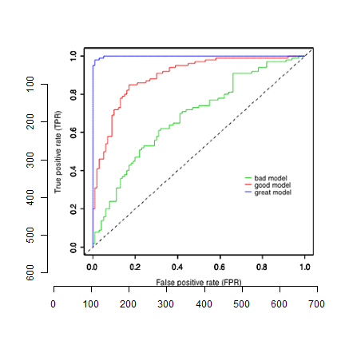

### SuperLearner

Super Learner uses V-fold cross-validation to build the optimal weighted combination of predictions from a library of candiate algorithms.

```r
#ModelOptions <- listWrappers()
ModelOptions[70:90]
```

```
 [1] "SL.bayesglm"        "SL.biglasso"        "SL.caret"
 [4] "SL.caret.rpart"     "SL.cforest"         "SL.dbarts"
 [7] "SL.earth"           "SL.extraTrees"      "SL.gam"
[10] "SL.gbm"             "SL.glm"             "SL.glm.interaction"
[13] "SL.glmnet"          "SL.ipredbagg"       "SL.kernelKnn"
[16] "SL.knn"             "SL.ksvm"            "SL.lda"
[19] "SL.leekasso"        "SL.lm"              "SL.loess"
```

### Fit GLM

```r
sl_glm = SuperLearner(Y = Y_train, X = X_train, family = binomial(), SL.library = "SL.glm")
pred_glm = predict(sl_glm, X_holdout)
ROC_eval("glm", pred_glm, Y_holdout)
```

```
[1] 0.826
```

### Glmnet Code

```r
SL.glmnet
```

```
function (Y, X, newX, family, obsWeights, id, alpha = 1, nfolds = 10,
    nlambda = 100, useMin = TRUE, loss = "deviance", ...)
{
    .SL.require("glmnet")
    if (!is.matrix(X)) {
        X <- model.matrix(~-1 + ., X)
        newX <- model.matrix(~-1 + ., newX)
    }
    fitCV <- glmnet::cv.glmnet(x = X, y = Y, weights = obsWeights,
        lambda = NULL, type.measure = loss, nfolds = nfolds,
        family = family$family, alpha = alpha, nlambda = nlambda,
        ...)
    pred <- predict(fitCV, newx = newX, type = "response", s = ifelse(useMin,
        "lambda.min", "lambda.1se"))
    fit <- list(object = fitCV, useMin = useMin)
    class(fit) <- "SL.glmnet"
    out <- list(pred = pred, fit = fit)
    return(out)
}
<bytecode: 0x00000000286d0470>
<environment: namespace:SuperLearner>
```

### Fit Lasso Regression

```r
sl_lasso = SuperLearner(Y = Y_train, X = X_train, family = binomial(), SL.library = "SL.glmnet")
pred_lasso = predict(sl_lasso, X_holdout)
ROC_eval("lasso", pred_lasso, Y_holdout)
```

```
[1] 0.823
```

### Ridge

```r
set.seed(904)
learners    = create.Learner("SL.glmnet", params = list(alpha = 0))
learners$names
```

```
[1] "SL.glmnet_1"
```

```r
sl_ridge = SuperLearner(Y = Y_train, X = X_train, family = binomial(), SL.library = "SL.glmnet_1")
pred_ridge = predict(sl_ridge, X_holdout)
ROC_eval("ridge", pred_ridge, Y_holdout)
```

```
[1] 0.824
```

### Ranger

```r
library(ranger)
set.seed(904)
sl_ranger = SuperLearner(Y = Y_train, X = X_train, family = binomial(), SL.library = "SL.ranger")
pred_ranger = predict(sl_ranger, X_holdout)
ROC_eval("ranger", pred_ranger, Y_holdout)
```

```
[1] 0.805
```

### K Support Vector Machine

```r
set.seed(904)
sl_ksvm = SuperLearner(Y = Y_train, X = X_train, family = binomial(), SL.library = "SL.ksvm")
pred_ksvm = predict(sl_ksvm, X_holdout)
ROC_eval("ksvm", pred_ksvm, Y_holdout)
```

```
[1] 0.818
```

```r
conv.preds_ksvm <- ifelse(pred_ksvm$pred >= 0.5, 1, 0)
```

### Stacked Model

```r
SL.library <- c("SL.glm", "SL.gam", "SL.glmnet", "SL.mean","SL.ranger", "SL.ksvm", "SL.glmnet_1")
set.seed(904)
sl_stacked = SuperLearner(Y = Y_train, X = X_train, family = binomial(), SL.library = SL.library, cvControl = list(V = 5))
sl_stacked
```

```
Call:
SuperLearner(Y = Y_train, X = X_train, family = binomial(), SL.library = SL.library,
    cvControl = list(V = 5))

                     Risk      Coef
SL.glm_All      0.1541189 0.1654709
SL.gam_All      0.1532209 0.2986596
SL.glmnet_All   0.1550442 0.0000000
SL.mean_All     0.2338019 0.0000000
SL.ranger_All   0.1587504 0.2792846
SL.ksvm_All     0.1672474 0.0000000
SL.glmnet_1_All 0.1532624 0.2565849
```

### Cross Validation Stacked Model

```r
set.seed(904)
cv_stacked <- CV.SuperLearner(Y = Y_train, X = X_train, family = binomial(), V = 5, SL.library = SL.library)
summary(cv_stacked)
```

```
Call:
CV.SuperLearner(Y = Y_train, X = X_train, V = 5, family = binomial(),
    SL.library = SL.library)

Risk is based on: Mean Squared Error

All risk estimates are based on V =  5

       Algorithm     Ave        se     Min     Max
   Super Learner 0.15198 0.0098372 0.13004 0.18385
     Discrete SL 0.15437 0.0105308 0.13306 0.18544
      SL.glm_All 0.15406 0.0107291 0.13255 0.18338
      SL.gam_All 0.15315 0.0106896 0.12697 0.18544
   SL.glmnet_All 0.15457 0.0102180 0.13406 0.18849
     SL.mean_All 0.23374 0.0061529 0.21603 0.26112
   SL.ranger_All 0.15907 0.0092870 0.13846 0.19020
     SL.ksvm_All 0.16681 0.0104059 0.13917 0.21396
 SL.glmnet_1_All 0.15320 0.0094776 0.13306 0.18340
```

### Cross Validation Stacked Model

```r
review_weights(cv_stacked)
```

```
                mean(weight)          sd       min       max
SL.gam_All       0.385820455 0.238482742 0.1128775 0.7165627
SL.ranger_All    0.204558810 0.113505946 0.0267607 0.3350836
SL.glmnet_1_All  0.184174172 0.240371284 0.0000000 0.5767654
SL.glm_All       0.144905097 0.200075472 0.0000000 0.3985920
SL.glmnet_All    0.076921885 0.118904090 0.0000000 0.2703285
SL.mean_All      0.003619581 0.008093629 0.0000000 0.0180979
SL.ksvm_All      0.000000000 0.000000000 0.0000000 0.0000000
```

### Cross Validation Stacked Model

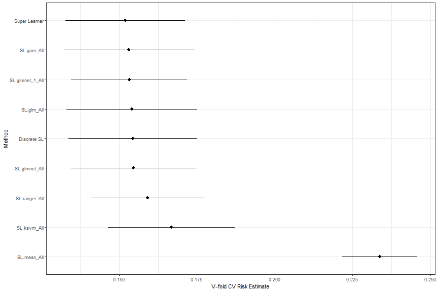

### Evaluate Test Set

```r
pred_sl <- predict.SuperLearner(sl_stacked, newdata = X_holdout, Y = Y_train, X = X_train)
ROC_eval("stacked", pred_sl, Y_holdout)
```

```
[1] 0.829
```

### Resources

```
[1] Unknown. _Unknown_. <URL:
https://poseidon01.ssrn.com/delivery.php?ID=560120086072066002018122074088002005063062020029025039112121…&EXT=pdf>.
Accessed 2018-11-25. 2018. <URL:
https://poseidon01.ssrn.com/delivery.php?ID=560120086072066002018122074088002005063062020029025039112121…&EXT=pdf>.
[1] Unknown. _Unknown_. <URL:
http://www.analyticsiowa.com/wp-content/uploads/2018/07/StatLearningNotesII.pdf>.
Accessed 2018-11-25. 2018. <URL:
http://www.analyticsiowa.com/wp-content/uploads/2018/07/StatLearningNotesII.pdf>.
```